# JHU - Simulation & Profiling

郭耀仁

2017-11-14

## 作業來源

[Coursera](https://www.coursera.org/) 的 [Programming with R](https://www.coursera.org/learn/r-programming) 課程第四週作業

## 資料集

[Assignment3-data](https://storage.googleapis.com/jhu_coursera_data/Assignment3-data.zip)

## 資料內容

- outcome-of-care-measures.csv 30 天心臟病就診資料
- hospital-data.csv 4,000+ 醫院的資訊
- Hospital_Revised_Flatfiles.pdf 編碼手冊

# 練習一

## 練習一說明

- 將 outcome-of-care-measures.csv 讀入，並且觀察第 11 個變數的分佈

```r
library(ggplot2)

outcome <- read.csv("~/Downloads/Assignment3-data/outcome-of-care-measures.csv", stringsAsFactors = FALSE)
outcome[, 11] <- as.numeric(outcome[, 11])
```

## 練習一範例

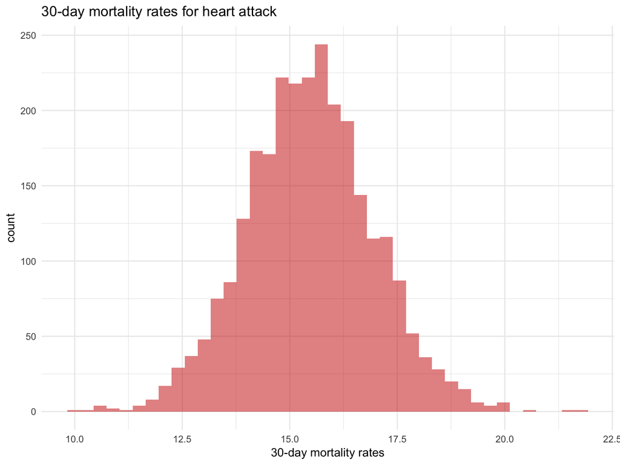

# 練習二

## 練習二函數結構

`best(state, outcome)`

找出指定州別裡面最好的醫院

## 練習二函數提示

- `outcome` 參數可以輸入 “heart attack”、“heart failure” 或 “pneumonia”
- 如果有兩個以上醫院的 outcome 相同，則依照字母順序排序後回傳
- `suppressWarnings()` 可以消除警告訊息
- 假如輸入無效的 `state` 名稱，使用 `stop()` 函數回傳訊息 invalid state
- 假如輸入無效的 `outcome` 參數，使用 `stop()` 函數回傳訊息 invalid outcome

## 練習二函數範例

```r
best("TX", "heart attack")
```

```
## [1] "CYPRESS FAIRBANKS MEDICAL CENTER"
```

```r
best("TX", "heart failure")
```

```
## [1] "FORT DUNCAN MEDICAL CENTER"
```

```r
best("MD", "heart attack")
```

```
## [1] "JOHNS HOPKINS HOSPITAL, THE"
```

```r
best("MD", "pneumonia")
```

```
## [1] "GREATER BALTIMORE MEDICAL CENTER"
```

```r
best("BB", "heart attack")
```

```
## Error in best("BB", "heart attack"): invalid state
```

```r
best("NY", "hert attack")
```

```
## Error in best("NY", "hert attack"): invalid outcome
```

# 練習三

## 練習三函數結構

`rankhospital(state, outcome, num = "best")`

將一個州依照 `outcome` 參數選出最好、最差或特定排名的醫院

## 練習三函數提示

- `outcome` 參數可以輸入 “heart attack”、“heart failure” 或 “pneumonia”
- 如果有兩個以上醫院的 outcome 相同，則依照字母順序排序後回傳
- 假如輸入無效的 `state` 名稱，使用 `stop()` 函數回傳訊息 invalid state
- 假如輸入無效的 `outcome` 參數，使用 `stop()` 函數回傳訊息 invalid outcome

## 練習三函數範例

```r
rankhospital("TX", "heart failure", 4)
```

```
## [1] "DETAR HOSPITAL NAVARRO"
```

```r
rankhospital("MD", "heart attack", "worst")
```

```
## [1] "HARFORD MEMORIAL HOSPITAL"
```

```r
rankhospital("MN", "heart attack", 5000)
```

```
## [1] NA
```

# 練習四

## 練習四函數結構

`rankall(outcome, num = "best")`

將全國的醫院依照 `outcome` 參數選出各州最好、最差或特定排名的醫院

## 練習四函數提示

- `outcome` 參數可以輸入 “heart attack”、“heart failure” 或 “pneumonia”
- 如果有兩個以上醫院的 outcome 相同，則依照字母順序排序後回傳
- 假如輸入無效的 `outcome` 參數，使用 `stop()` 函數回傳訊息 invalid outcome

## 練習四函數範例

```r
head(rankall("heart attack", 20), 10)
```

```
##                               hospital state
## 1                                 <NA>    AK
## 2       D W MCMILLAN MEMORIAL HOSPITAL    AL
## 3    ARKANSAS METHODIST MEDICAL CENTER    AR
## 4  JOHN C LINCOLN DEER VALLEY HOSPITAL    AZ
## 5                SHERMAN OAKS HOSPITAL    CA
## 6             SKY RIDGE MEDICAL CENTER    CO
## 7              MIDSTATE MEDICAL CENTER    CT
## 8                                 <NA>    DC
## 9                                 <NA>    DE
## 10      SOUTH FLORIDA BAPTIST HOSPITAL    FL
```

```r
tail(rankall("pneumonia", "worst"), 3)
```

```
##                                      hospital state
## 52 MAYO CLINIC HEALTH SYSTEM - NORTHLAND, INC    WI
## 53                     PLATEAU MEDICAL CENTER    WV
## 54           NORTH BIG HORN HOSPITAL DISTRICT    WY
```

```r
tail(rankall("heart failure"), 10)
```

```
##                                                             hospital state
## 45                         WELLMONT HAWKINS COUNTY MEMORIAL HOSPITAL    TN
## 46                                        FORT DUNCAN MEDICAL CENTER    TX
## 47 VA SALT LAKE CITY HEALTHCARE - GEORGE E. WAHLEN VA MEDICAL CENTER    UT
## 48                                          SENTARA POTOMAC HOSPITAL    VA
## 49                            GOV JUAN F LUIS HOSPITAL & MEDICAL CTR    VI
## 50                                              SPRINGFIELD HOSPITAL    VT
## 51                                         HARBORVIEW MEDICAL CENTER    WA
## 52                                    AURORA ST LUKES MEDICAL CENTER    WI
## 53                                         FAIRMONT GENERAL HOSPITAL    WV
## 54                                        CHEYENNE VA MEDICAL CENTER    WY
```